# Estimating variability: From A, B, C to Tau, Sigma, Psi

#### 2.13.3.2 A working example

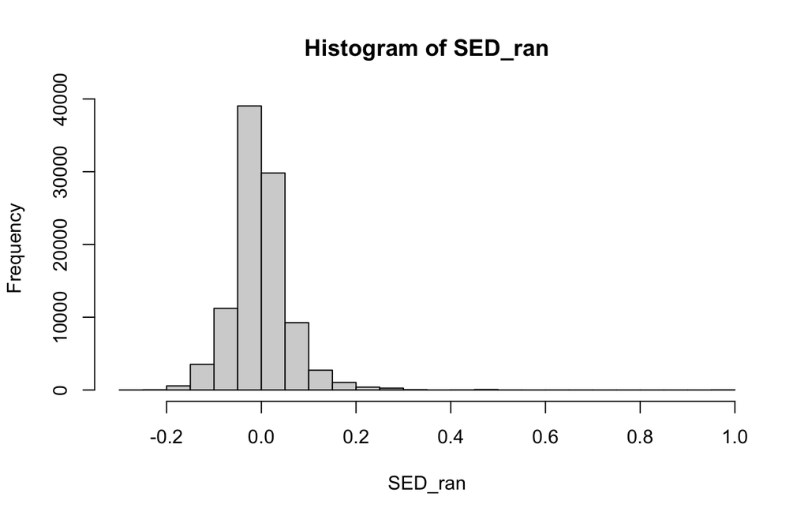

```r
# compute SED
SED_ran <- vector()
for (row in 1:nrow(ran_simdat)) {SED_ran[row] <- SED(ran_simdat[row,])}

# view distribution and mean
hist(SED_ran)
```

```r
t.test(SED_ran, na.rm = T)
```

```
    One Sample t-test

data:  SED_ran
t = 0.29774, df = 97999, p-value = 0.7659
alternative hypothesis: true mean is not equal to 0
95 percent confidence interval:
 -0.0003230241  0.0004387450
sample estimates:
   mean of x
5.786044e-05
```

```r
cor.test(SED_ran, ran_p)
```

```
    Pearson's product-moment correlation

data:  SED_ran and ran_p
t = -0.33166, df = 97998, p-value = 0.7401
alternative hypothesis: true correlation is not equal to 0
95 percent confidence interval:
 -0.007320311  0.005201454
sample estimates:
        cor
-0.00105947
```

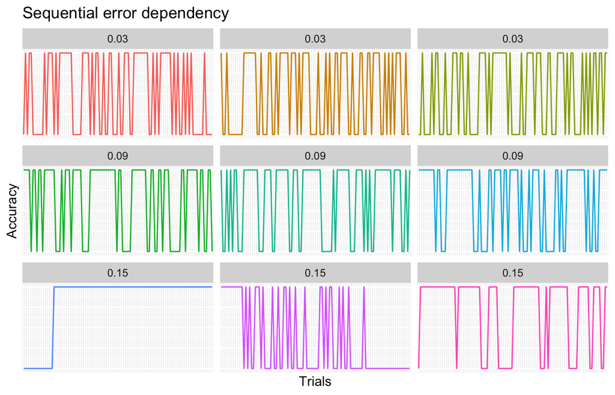

```r
# compute in the realistic data set and plot example trajectories
SED_real <- vector()
for (row in 1:nrow(real_simdat)) {SED_real[row] <- SED(real_simdat[row,])}
plot_meas(real_simdat, SED_real, "Sequential error dependency")
```

### 2.13.4 Windowed Variance

While we cannot compute a meaningful variance over binary data, we can break up the time series in a set of windows and compute a variance over the means of these windows. Say we have a time series of length $T$, and use a window size $w$. We can compute the number of windows of size $w$ that fit into a time series of length $T$ using integer division:

$$f = \lfloor T / w \rfloor$$

We only keep the trials that are part of a full window, which means all trials in the remainder of the time series are discarded. Next, we can compute a mean for each of the $f$ full windows in our time series. The windowed variance is computed as the variance of the set of window means:

$$\text{winVar}_{\text{raw}} = \frac{\sum_{j=1}^{f} (\bar{y}_{j} - \bar{\bar{y}})^2}{f-1}$$
Where $\bar{\bar{x}}$ represents the mean over the window means, which means it does not include the trials in the remainder. We can imagine alternative procedures for computing the windowed variance, such as a procedure where the remainder trials are counted as an extra remainder window. However, including such a remainder window would make the standardization of the measure much more complex. This means that, whenever the time series length is not a multiple of the window size, some trials will not be included in the computation.

We can residualize the raw windowed variance by subtracting the expected windowed variance. We know that in a binary time series with proportion correct $p$, the variance is equal to $p \cdot (1-p)$. Now, when we cut up the binary time series into windows, we are “tempering” the variance, as each window mean tends towards the global mean with increasing window size. We can also understand each window as a sample from the full time series, where we are interested in the sampling variance across windows. Given that we know the “population variance”, i.e. the variance of the full time series, the expected variance across windows is equal to $\text{Var}(y_{\text{full}}) / w$, which is the variance of the full time series divided by the window size.

Now we still need the maximum and minimum possible windowed variances. For the maximum variance, we need the contrasts between windows to be as large as possible. This comes down to reordering the time series so that the first part contains all the 1s, and the second part contains all the 0s. This results in at least $f-1$ windows containing either only 1s, or only 0s.

For the minimum variance, we want all window means to be as close together as possible. For this, we have to perform integer division on the number of correct trials, $k$, and the window size. Say that $k = 83$ and $w = 10$ for a time series of length $T = 100$; then $k/w$ results in 8 with a remainder of 3. This means we need 3 windows with $8+1=9$ correct trials, and $f-3 = 7$ windows with 8 correct trials. When the remainder is 0, all windows have an equal amount of trials, resulting in a variance of 0.

Finally, we can range-standardize both the raw and the expected windowed variance and subtract them, which results in a standardized windowed variance.

#### 2.13.4.1 Function

Click “show” to view the implementation of the windowed variance computation in an R function.

```r
# Main function
# Input time series, specify output
# The default output is "standardized"
# Other options for output are: "raw", "range-std"
# main function for computing raw, range-std, and standardized windowed variance
winVar = function(ts, output = "standardized", w = 10) {

  # deletes NAs at the end of the ts
  ts <- if (all(is.na(ts))) NA else ts[seq_len(max(which(!is.na(ts))))]

  # checks whether the ts include missing data and returns error message if so
  if (sum(is.na(ts)) > 0)
  {stop("Data includes missingness; please input a data set without missing values")}

  # compute number of full windows that fit into the ts, cut off remaining trials
  f = length(ts) %/% w # nr of full windows of length w
  ts_full = ts[1:(w*f)] # ts with full windows
  k = sum(ts_full) # nr of 1s
  n_full = length(ts_full)

  # compute raw windowed variance; return if output == "raw"
  raw_winVar = winVar_raw(ts_full, w, f)
  if (output == "raw") {return(raw_winVar)}

  # compute predicted variance
  # note: we use var(ts)/w instead of (p* (1-p)/w for consistency)
  pred_Var = var(ts_full) / w

  # compute min and max; compute range-standardized measure
  max_var = (winVar_max(ts_full, k, w, f))
  min_var = (winVar_min(ts_full, f, k, w))
  range_var = round(max_var - min_var, digits = 10)
  winVar_std = ((raw_winVar - min_var) / range_var)
  if (output == "range-std") return(winVar_std)

  # compute standardized variance
  winVar_res = winVar_std - ((pred_Var - min_var) / range_var)
  return(winVar_res)
}

# helper function to compute raw windowed variance
winVar_raw = function(ts_full, w, f) {

  # create vector for saving window means, compute means for the full windows
  w_means = vector()
  for (win in 1:f) { ind = (win-1)*w+1
  w_means[win] = mean(ts_full[ind:(ind+w-1)])}
  # compute the variance over the means and return
  raw_var = var(w_means)
  return(raw_var)
}

# helper function for computing the minimum winVar
winVar_min <- function(ts_full, f, k, w) {
  spr = k %/% f
  rem = k %% f
  if (rem == 0) {return(0)}
  else {
    counts = c(rep(spr+1, rem), rep(spr, (f-rem)))
    min_ts = unlist(lapply(counts, function(cn) c(rep(1, cn), rep(0, w - cn))))
    return(winVar_raw(min_ts, w, f))
  }
}

# helper function for computing the maximum winVar
winVar_max <- function(ts_full, k, w, f) {
  max_ts = c(rep(1,k), rep(0, length(ts_full)-k))
  return(winVar_raw(max_ts, w, f))
}
```